# Variáveis aleatórias e Probabilidade

Rafael Bassi Stern

02 de abril de 2018

# Variáveis aleatórias

É comum que desejemos generalizar as conclusões que obtemos de um banco de dados para uma população. Por exemplo, no banco de dados de adubos, amostras de adubo com fosfato em geral tem um efeito maior que amostras de adubo sem fosfato. Será verdade, fora de nossa amostra, que adubos com fosfato tem efeito superior a adubos sem fosfato?

Para responder a questões como essa, é preciso desenvolver uma ferramenta que ligue as observações realizadas na amostra a observações futuras. Para realizar esta conexão descrevemos o nosso conhecimento antes de coletar o banco de dados. Neste contexto, havia incerteza sobre quais dados seriam observados. Por exemplo, considere que um experimento consiste em medir um objeto 10 vezes com um paquímetro. Devido aos erros de medição diversos valores serão observados. Cada medição tem um resultado incerto, com vários possíveis valores.

Para designar observações incertas, usamos **variáveis aleatórias**. Em particular, lembre-se que um banco de dados é uma matriz em que as linhas são unidades amostrais e as colunas são variáveis. Designamos por $X_{i,j}$ o valor observado para a $j$-ésima variável da $i$-ésima unidade amostral. Como descrevemos nossa incerteza em um momento anterior à coleta do banco de dados, o valor de $X_{i,j}$ é incerto.

## Proposições

Utilizando variáveis aleatórias, é possível definir **proposições** de interesse. Proposições simples envolvem uma única variável e são, por exemplo, “$X_{1,3} = 5.2$”, “$X_{4,2} \geq 4$” ou “$X_{1,1} \leq 1$”. Também é possível obter proposições complexas unindo proposições simples por meio de conjunções. Por exemplo, “$X_{1,1} = 2$ **e** $X_{2,1} = 2$” e “$X_{1,3} = 5$ **ou** $X_{1,3} = 4$”. Se $A$ e $B$ são duas proposições, dizemos que a proposição $A$ **e** $B$ é observada se e somente se tanto $A$ quanto $B$ são observadas. Por exemplo, “choveu hoje **e** choveu ontem” é observado se e somente se “choveu hoje” é observado e também “choveu ontem” é observado. Similarmente, se $A$ e $B$ são duas proposições, dizemos que a proposição $A$ **ou** $B$ é observada se e somente se somente $A$ é obsevada, somente $B$ é observada ou tanto $A$ quanto $B$ são observadas. Por exemplo, “choveu hoje **ou** choveu ontem” somente não é observado se tanto “choveu hoje” não é observado quanto “choveu hoje” não é observado. A seguir, desenvolvemos uma medida de plausibilidade para proposições.

# Probabilidade

A probabilidade de uma proposição é uma medida de quão plausível esta proposição é. Seja $A$ uma proposição, designamos sua probabilidade por $P(A)$. Por exemplo, seja $X_{1,1}$ o peso em kg do primeiro boi em um amostra. $P(X_{1,1} > 500)$ designa a probabilidade de que o peso desse boi seja maior do que 500 kg.

A probabilidade tem certas propriedades que ela deve satisfazer. Primeiramente, para toda proposição a sua probabilidade deve estar entre 0 e 1. Se $P(A) = 0$, $A$ é impossível e se $P(A) = 1$, $A$ é certo. Para todo outro valor de $P(A)$, $A$ é incerto, sendo que, quanto maior o valor de $P(A)$, mais plausível é $A$. A seguir, estudaremos algumas propriedades adicionais da probabilidade.

## Relações entre proposições

- Dizemos que duas proposições são **mutuamente exclusivas** se é impossível que ambas ocorram simultaneamente. Isto é, $A$ e $B$ são mutuamente exclusivas se “$A$ **e** $B$” é impossível. Por exemplo, se $X$ é uma variável aleatória que designa o resultado de uma moeda, então “$X$ = cara” e “$X$ = coroa” são mutuamente exclusivas. É uma propriedade da probabilidade que, se $A$ e $B$ são proposições mutuamente exclusivas, então:
  $$P(A \textbf{ ou } B) = P(A) + P(B).$$
- Dizemos que duas proposições são **independentes** se aprender uma proposição não traz informação sobre a outra. Por exemplo, considere que $X_{1}$ e $X_{2}$ designam o resultado de dois lançamentos separados de um dado. Usualmente, não acreditamos que um lançamento de um dado traz informação sobre o outro. Assim, por exemplo, $X_{1}=1$ é independente de $X_{2}=3$. se $A$ e $B$ são proposições independentes, então:
  $$P(A \textbf{ e } B) = P(A) \cdot P(B).$$
- Dizemos que duas variáveis aleatórias, $X$ e $Y$, são independentes se qualquer par de proposições sobre $X$ e $Y$ são independentes. Por exemplo, se $X$ e $Y$ são independentes, então $X = 2$ e $Y > 3$ são independentes. Para muitos bancos de dados que estudaremos neste curso, será comum supormos que, para toda variável, $j$, as observações desta variável são independentes para cada unidade amostral. Isto é, $X_{1,j}, X_{2,j}, \ldots, X_{n,j}$ são independentes.
- **Atenção**: Exceto em casos extremos, um par de proposições nunca é simultaneamente “mutuamente exclusivo” e “independente”. De fato, se $A$ e $B$ são mutuamente exclusivos e aprendemos que $A$ ocorreu, então sabemos com certeza que $B$ não ocorreu. Isto é, $A$ traz informação sobre $B$. Estes conceitos sejam frequentemente confundidos! Tome cuidado!

## Interpretações da probabilidade.

### Simetria

Os conceitos de probabilidade iniciaram seu desenvolvimento com o estudo de jogos de azar. Isto ocorreu provavelmente porque nestes jogos lidamos com incertezas em um ambiente controlado. O funcionamento de um dado é relativamente simples em relação ao objeto de pesquisas científicas modernas.

Por exemplo, os possíveis resultados do lançamento de um dado (1, 2, 3, 4, 5 e 6) são **simétricos** e, assim, todos são igualmente plausíveis. Neste caso, obtemos que a probabilidade de cada possibilidade é $1$ sobre o número total de possibilidades. Por exemplo, se $X$ é uma variável aleatória que designa o resultado do dado, então $P(X=1) = \frac{1}{6}$. Semelhantemente,

$$P(X=1 \textbf{ ou } X=3) = P(X=1) + P(X=3) = \frac{1}{6} + \frac{1}{6} = \frac{2}{6}$$

### Frequência

Na maior parte de pesquisas científicas modernas, nãoé possível usar diretamente o juízo de simetria apresentado anteriormente. Por exemplo, quando realizamos uma reação química, esta pode produzir o efeito desejado ou não. Em geral, estas possibilidades não são igualmente plausíveis. Assim, é necessário desenvolver um conceito mais abrangente de probabilidade.

Para tal, imaginamos uma sequência de experimentos independentes em que realizamos a reação química estudada. Podemos calcular a proporção de experimentos tais que a reação química produziu o efeito desejado. Ainda que, para um número finito de experimentos, esta proporção apresente variabilidade, quando o número o número de experimentos torna-se grande, a proporção concentra-se em um valor. Segundo a interpretação baseada em **frequências**, este valor designa a probabilidade de a reação química produzir o resultado satisfatório. Isto é, a probabilidade de que a reação química produza um resultado satisfatório é a proporção de experimentos independentes em que obtemos este resultado, quando realizamos um número muito grande de experimentos.

Por exemplo, a figura abaixo apresenta a proporção de vezes que um evento ocorre para vários possíveis números de realizações de experimentos independentes. Qual a probabilidade de ocorrência do evento?

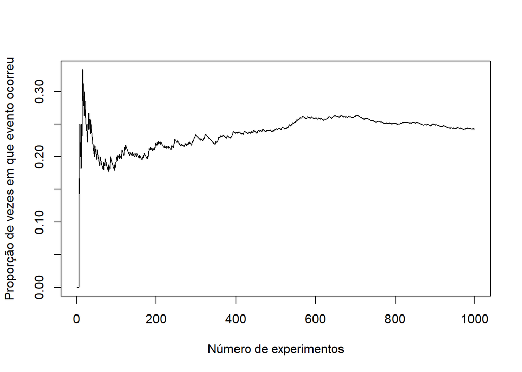

### Apostas

Existem experimentos tais que não conseguimos imaginar repetições independentes. Por exemplo, imagine as eleições presidenciais de 2018 como experimento. Existirá uma única eleição presidencial de 2018 e, assim, não conseguimos imaginar uma sequência de repetições independentes deste experimento. Assim, a interpretação frequentista não consegue responder a questões como: “Qual a probabilidade de o candidato $A$ vencer as eleições presidenciais de 2018?”

Neste sentido, existe uma interpretação alternativa de probabilidade baseada em apostas. Considere uma aposta em que você ganha R$1 se uma proposição, $A$, ocorrer e R$0, caso contrário. Note que, caso você pague $p$ para participar desta aposta, então ganhará R$(1-p) caso $A$ ocorra e perderá R$p caso $A$ não ocorra. Segundo a interpretação baseada em apostas, a probabilidade de $A$ é o maior valor que você estaria disposto a pagar para participar desta aposta.

Possíveis vantagens da interpretação baseada em apoastas é que ela enfatiza que o juízo de probabilidade é subjetivo e que ela pode ser aplicada a experimentos que não podem ser repetidos.

# Exercícios

1. Descreva em suas próprias palavras o significado de “mutuamente exclusivos” e “independentes”. Apresente um exemplo de um par de proposições para cada expressão.
2. Considere as proposições: A = “Choverá hoje” e B = “Não choverá hoje”. Elas são mutuamente exclusivas? São independentes?
3. Considere as proposições: A = “Choverá hoje” e B = “Choverá amanhã”. Elas são mutuamente exclusivas? São independentes?
4. Um dado de 6 faces é arremessado. Qual é a probabilidade de que, $A$, um número par seja sorteado? Qual é a probabilidade de que, $B$, o número 3 ou 6 seja sorteado? As duas proposições acima são independentes? Verifique se $P(A \textbf{ e } B) = P(A) \cdot P(B)$.
5. Dividam-se em grupos e arremessem uma moeda várias vezes. Construam um banco de dados juntando todos os seus lançamentos. Para este banco de dados, esbocem como a proporção de caras varia de acordo com o número de lançamentos.
6. Uma moeda de duas faces simétricas é arremessada duas vezes. Seja $A$ a proposição de que o resultado do primeiro lançamento foi cara e $B$ a proposição de que em ambos os lançamentos ocorreu o mesmo resultado.
1. Determine $P(A)$, $P(B)$, $P(A \textbf{ ou } B)$ e $P(A \textbf{ e } B)$.
2. $A$ e $B$ são independentes? São mutuamente exclusivos?